# Statistical Analysis Handout for the Market Segmentation Lecture

This handout is designed to help you replicate the statistical analyses that were covered in the Market Segmentation lecture. You should have this handout handy when you work on the (Market Segmentation) programming assignment where you will be asked to apply the learnings from the lecture on a different dataset.

# Cluster Analysis

Cluster Analysis refers to a class of techniques used to classify individuals into groups such that:

- Individuals within a group should be as similar as possible
- Individuals belonging to different groups should be as dissimilar as possible

This handout shows three different cluster analysis techniques:

1. Hierarchical clustering
2. K-Means
3. Latent Class Analysis

In order to run these statistical methods, you need to install these R packages:

- NbClust
- mclust
- gmodels

```r
set.seed(1990)
library(NbClust)
library(mclust)
library(dbscan)
library(gmodels)
library(here)
library(tidyverse)
library(cluster)
library(Rtsne)
```

# Reading and outputing data

The dataset includes data from 73 students (24 MBAs and 49 undergrads). These students were asked to allocate 100 points across six automobile attributes (Trendy, Styling, Reliability, Sportiness, Performance, and Comfort) in a way that reflects their importance in the purchase decision of which car to buy. We use this dataset to answer the following questions:

1. Are there different benefit segments among this student population?
2. How many segments?
3. How are they different in their constant-sum allocation?
4. How can we transform this information into actionable levers from a managerial standpoint?

Let us start by reading the data. Remember to start by setting the appropriate directory using the following code

```r
setwd("your_directory")
```

We can now read the raw data:

```r
seg_data <- read.csv(file = "./data/SegmentationData.csv",row.names=1)
head(seg_data)
```

|  | Trendy | Styling | Reliability | Sportiness | Performance | Comfort | MBA | Choice |
| --- | --- | --- | --- | --- | --- | --- | --- | --- |
| 1 | 10 | 20 | 35 | 5 | 20 | 10 | MBA | Lexus |
| 2 | 25 | 5 | 25 | 5 | 25 | 15 | MBA | BMW |
| 3 | 10 | 20 | 30 | 10 | 10 | 20 | MBA | Lexus |
| 4 | 10 | 15 | 30 | 10 | 20 | 15 | MBA | BMW |
| 5 | 20 | 10 | 40 | 1 | 14 | 15 | MBA | Mercedes |
| 6 | 20 | 30 | 10 | 20 | 10 | 10 | MBA | Lexus |

# Preprocessing Steps

- removing outliers or use method less sensitive to outliers (e.g. DBSCAN)
- scaling data
- For latent class analysis and NBclust, remove one column as covariance would not be useful

# Hierarchical Clustering Analysis

Hierarchical Clustering Analysis is one of the most popular technique used for market segmentation. It is a numerical procedure which attempts to separate a set of observations into clusters from the bottom-up by joining single individuals sequentially until we obtain one large cluster. Hence, this technique doesn’t require the pre-specification of the number of clusters,which can be assessed through the “dendogram” (a tree-like representation of the data).

More specifically, the algorithm works as follow (slide 22 onwards):

1. Each respondent is initially assigned to his or her own cluster
2. Identify the distance between each cluster (intially between pairs of respondents)
3. The two closest clusters are combined into one
4. Repeat steps 2 and 3 until there is one unique cluster containing all the observations
5. Represent the clusters in a dendogram

A key aspect of hierarchical clustering consists in choosing how to compute the distance between two clusters. Is it equal to the maximal distance between two points from each of these clusters? Or the minimal distance? What about the distance between two points? In this handout, we will use Ward’s criterion which aims to minimize the total variance within-cluster. To do so, we use the R function hclust. We start by standardizing the data so that every variable is on the same scale. We then compute the euclidean distance between observations.

```r
std_seg_data <- scale(seg_data[,c("Trendy", "Styling", "Reliability", "Sportiness", "Performance", "Comfort")])
dist <- dist(std_seg_data, method = "euclidean")
as.matrix(dist)[1:5,1:5]
```

```
         1        2        3        4        5
1 0.000000 3.730216 2.802191 1.775616 2.746615
2 3.730216 0.000000 4.218662 3.017462 2.984534
3 2.802191 4.218662 0.000000 1.974683 3.331082
4 1.775616 3.017462 1.974683 0.000000 2.924141
5 2.746615 2.984534 3.331082 2.924141 0.000000
```

We now use the function hclust() to apply hierarchical clustering on our data. We use the Ward criterion which aims to minimize the within-cluster variance. \ We obtain the dendogram below which can help us decide the number of clusters to retain. This number seems to be either 3 or 4. \ Note: It is important to set the seed to a specific value. This way you would always get the same labeling of the clusters. Otherwise, cluster 1 in one analysis may correspond to cluster 3 in another.

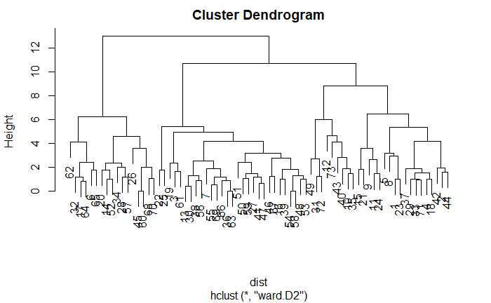

```r
set.seed(1990)
clust <- hclust(dist, method = "ward.D2")
plot(clust)
```

## The four-cluster solution

We start by 4 clusters as we see below:

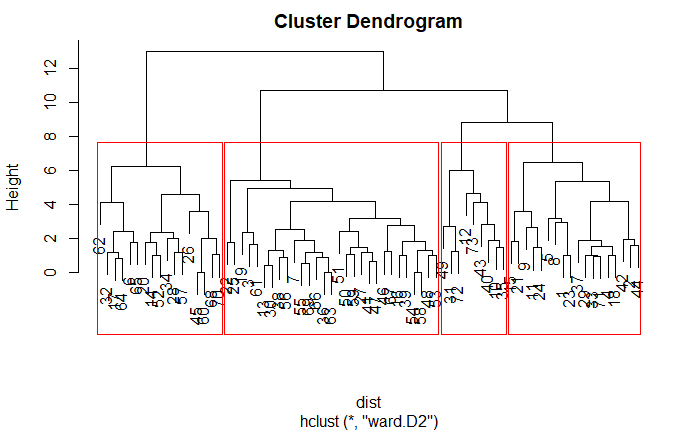

```r
set.seed(1990)
clust <- hclust(dist, method = "ward.D2")
plot(clust)
rect.hclust(clust, k=4, border="red")
```

```r
h_cluster <- cutree(clust, 4)
```

Let us now look at some description of this clustering. The table below informs us with the number of individuals in each cluster:

```r
table(h_cluster)
```

```
h_cluster
 1  2  3  4
18 29 17  9
```

The table below reports the profiles of the four clusters (i.e., the clustering variables means by cluster). Looking at this table, we can describe the clusters as follows:

```r
hclust_summary <- aggregate(std_seg_data[,c("Trendy", "Styling", "Reliability", "Sportiness", "Performance", "Comfort")],by=list(h_cluster),FUN=mean)
hclust_summary
```

| Group.1 | Trendy | Styling | Reliability | Sportiness | Performance | Comfort |
| --- | --- | --- | --- | --- | --- | --- |
| 1 | -0.50357227 | -0.6837159 | 1.09976574 | -0.94569654 | 0.6548024 | 0.08642535 |
| 2 | -0.01577854 | -0.4249072 | -0.28158545 | 0.50052114 | -0.0989237 | 0.58621035 |
| 3 | 1.14725137 | 0.8552172 | -0.65660558 | 0.16346240 | -0.9192806 | -0.69794311 |
| 4 | -1.10904387 | 1.1211667 | -0.05194561 | -0.03015957 | 0.7455682 | -0.74341374 |

## Three-Cluster Solution

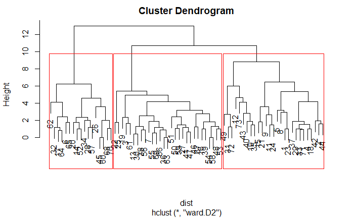

```r
plot(clust)
h_cluster <- cutree(clust, 3)
rect.hclust(clust, k=3, border="red")
```

```r
table(h_cluster)
```

```
h_cluster
 1  2  3
27 29 17
```

```r
hclust_summary <- aggregate(std_seg_data[,c("Trendy", "Styling", "Reliability", "Sportiness", "Performance", "Comfort")],by=list(h_cluster),FUN=mean)
hclust_summary
```

| Group.1 | Trendy | Styling | Reliability | Sportiness | Performance | Comfort |
| --- | --- | --- | --- | --- | --- | --- |
| 1 | -0.70539614 | -0.08208834 | 0.7158620 | -0.6405175 | 0.6850577 | -0.1901877 |
| 2 | -0.01577854 | -0.42490717 | -0.2815854 | 0.5005211 | -0.0989237 | 0.5862104 |
| 3 | 1.14725137 | 0.85521724 | -0.6566056 | 0.1634624 | -0.9192806 | -0.6979431 |

This solution seems to have clusters of similar sizes. In addition, we can easily caracterize each of them. The first cluster cares about Performance and Reliability while Cluster 2 values Comfort and Sportiness. Finally, the third cluster cares about the appearance. Below, we rename those clusters according to their characteristics.

```r
h_cluster <- factor(h_cluster,levels = c(1,2,3),
                    labels = c("Perf.", "Comfort", "Appearance"))
```

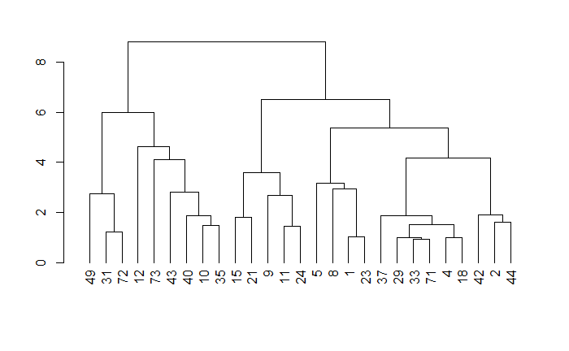

```r
plot(cut(as.dendrogram(clust), h=9)$lower[[3]])
```

## Number of Clusters

As seen above, one can use the dendogram to decide on the appropriate number of clusters. The function NbClust examines all the indexes/criteria used to determine the optimal number of clusters and outputs the optimal number based on the majority rule. Note that since it’s a constant-sum allocation, we must use only 5 variables to avoid collinearity issues.

```
*** : The Hubert index is a graphical method of determining the number of clusters.
                In the plot of Hubert index, we seek a significant knee that corresponds to a
                significant increase of the value of the measure i.e the significant peak in Hubert
                index second differences plot.
```

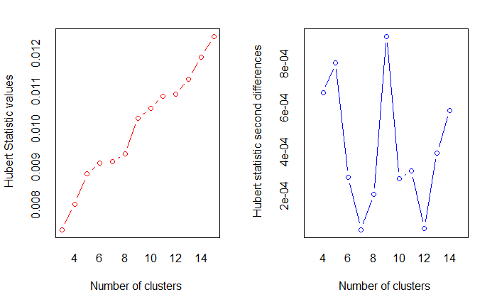

```
*** : The D index is a graphical method of determining the number of clusters.
                In the plot of D index, we seek a significant knee (the significant peak in Dindex
                second differences plot) that corresponds to a significant increase of the value of
                the measure.

* Among all indices:
* 7 proposed 3 as the best number of clusters
* 2 proposed 4 as the best number of clusters
* 2 proposed 5 as the best number of clusters
* 2 proposed 6 as the best number of clusters
* 4 proposed 9 as the best number of clusters
* 3 proposed 12 as the best number of clusters
* 1 proposed 13 as the best number of clusters
* 2 proposed 15 as the best number of clusters

                   ***** Conclusion *****

* According to the majority rule, the best number of clusters is  3


$All.index
       KL      CH Hartigan     CCC    Scott   Marriot    TrCovW   TraceW Friedman  Rubin Cindex     DB Silhouette   Duda Pseudot2   Beale Ratkowsky    Ball Ptbiserial
3  4.2356 19.1708   9.1557 -3.8247 125.3102 546888028 3415.0147 232.5975   5.4783 1.5477 0.4026 1.6869     0.1987 0.6935   6.6287  1.2967    0.3432 77.5325     0.4553
4  0.3189 17.2540   8.3534 -5.0953 159.1836 611300402 2593.8512 205.6938   7.0207 1.7502 0.3825 1.5521     0.2111 0.7443   7.2126  1.0261    0.3267 51.4234     0.4936
5  0.5079 16.3550   8.9849 -6.0343 202.7795 525669059 2134.0463 183.4809   8.8405 1.9621 0.3560 1.5191     0.2206 0.5410   6.7863  2.3600    0.3123 36.6962     0.5216
6  1.2239 16.3655   7.4554 -5.4291 240.3721 452300734 1641.4307 162.0669  10.4134 2.2213 0.4427 1.3403     0.2335 0.3851  11.1763  4.3725    0.3017 27.0112     0.5383
7  0.9987 16.1533   6.8924 -5.0795 272.0101 399115542 1309.7081 145.8389  11.7806 2.4685 0.4429 1.1950     0.2414 0.6398   6.7563  1.6266    0.2912 20.8341     0.5458
8  0.8637 16.0296   7.0554 -4.7518 305.5157 329419867 1063.7346 132.0490  13.4009 2.7263 0.4268 1.1583     0.2445 0.7768   8.9079  0.8713    0.2811 16.5061     0.5535
9  1.0446 16.1775   6.6456 -4.2941 344.2663 245198975  894.1088 119.1193  15.5956 3.0222 0.3921 1.1251     0.2550 0.7288  10.7909  1.1258    0.2725 13.2355     0.5828
10 0.9691 16.3520   6.6364 -3.8667 376.7922 193878168  720.2895 107.9138  17.7061 3.3360 0.3630 1.2087     0.2093 0.4678   4.5515  2.8491    0.2644 10.7914     0.5028
11 1.2274 16.6619   5.7269 -3.3850 405.2744 158805977  566.4595  97.6295  19.4921 3.6874 0.4062 1.1481     0.2253 0.3736   5.0300  3.9357    0.2573  8.8754     0.5089
12 1.4727 16.7917   4.4283 -3.0689 430.4837 133803651  464.2880  89.3741  21.0350 4.0280 0.4749 1.0742     0.2312 0.7289   7.8114  1.1113    0.2502  7.4478     0.5125
13 0.9527 16.6021   4.4291 -3.0135 462.2226 101664547  418.1911  83.3250  23.7505 4.3204 0.4593 1.1319     0.2094 0.5973   3.3715  1.7587    0.2429  6.4096     0.4248
14 1.0413 16.5171   4.2289 -2.9133 490.8040  79707962  370.8162  77.5969  25.9989 4.6394 0.4458 1.1454     0.2167 0.5413   5.9328  2.3211    0.2365  5.5426     0.4268
15 0.9571 16.4550   4.2829 -2.8227 517.1570  63774583  329.0855  72.4071  28.2284 4.9719 0.4303 1.1209     0.2158 1.9784  -0.9891 -1.0319    0.2305  4.8271     0.4257
      Frey McClain   Dunn Hubert SDindex Dindex   SDbw
3  -0.0754  1.2360 0.1677 0.0074  2.5719 1.6213 0.9774
4   0.1486  1.3198 0.1677 0.0080  2.2785 1.5292 0.9946
5  -0.0562  1.5473 0.1686 0.0088  2.2161 1.4514 0.6734
6   0.0428  1.5724 0.2159 0.0091  1.9374 1.3769 0.5657
```

[output cut: 24 more lines]

```
15        -0.0536           -39.3104       1.0000

$Best.nc
                    KL      CH Hartigan     CCC   Scott  Marriot   TrCovW TraceW Friedman   Rubin Cindex      DB Silhouette   Duda PseudoT2  Beale Ratkowsky    Ball
Number_clusters 3.0000  3.0000   6.0000 15.0000  5.0000        9   4.0000 6.0000  13.0000 12.0000  5.000 12.0000      9.000 3.0000   3.0000 3.0000    3.0000  4.0000
Value_Index     4.2356 19.1708   1.5295 -2.8227 43.5959 32900086 821.1635 5.1859   2.7154 -0.0482  0.356  1.0742      0.255 0.6935   6.6287 1.2967    0.3432 26.1091
                PtBiserial Frey McClain  Dunn Hubert SDindex Dindex    SDbw
Number_clusters     9.0000    2   3.000 12.00      0  9.0000      0 15.0000
Value_Index         0.5828   NA   1.236  0.23      0  1.7508      0  0.3038

$Best.partition
 1  2  3  4  5  6  7  8  9 10 11 12 13 14 15 16 17 18 19 20 21 22 23 24 25 26 27 28 29 30 31 32 33 34 35 36 37 38 39 40 41 42 43 44 45 46 47 48 49 50 51 52 53 54 55 56
 1  1  1  2  1  3  2  2  1  2  1  2  2  3  1  2  3  2  3  3  1  2  1  1  3  3  2  3  2  2  3  3  2  3  3  2  1  2  2  1  2  1  2  1  3  2  2  2  1  2  1  3  2  2  2  2
57 58 59 60 61 62 63 64 65 66 67 68 69 70 71 72 73
 3  2  2  3  3  3  2  3  3  2  2  3  2  3  2  3  1
```

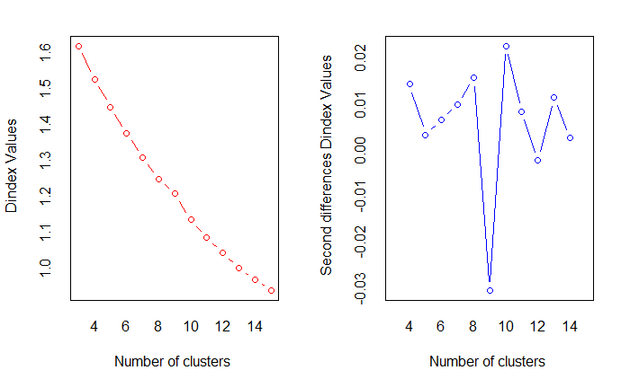

```r
set.seed(1990)
NbClust(data=std_seg_data[,1:5], min.nc=3, max.nc=15, index="all", method="ward.D2")
```